# Stat437 Lecture 1b

#### Density Plot

used to: - visually check the model assumptions - visually compare a response’s behavior under different conditions

when it comes to diagnostics, We don’t even need q-q plot if we estimate density properly

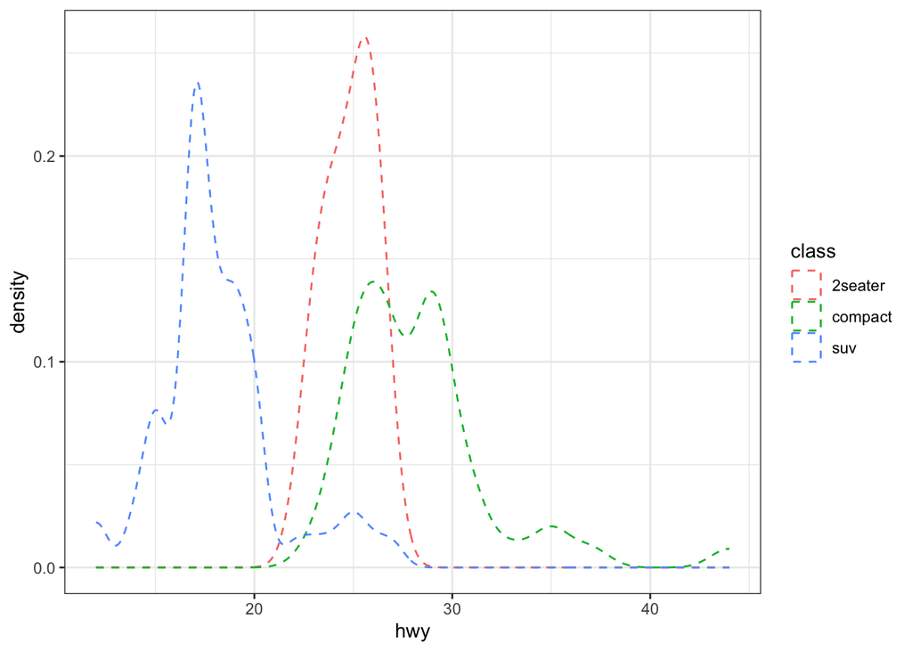

$\mu = E(X) = \int_a^b x f(X) dx = x_0 f(x_0) (b-a)$ for some $x_0 \in [a,b]$ by Mean Value Theorem

#### Histogram

Create a histogram for hwy for each of 3 class

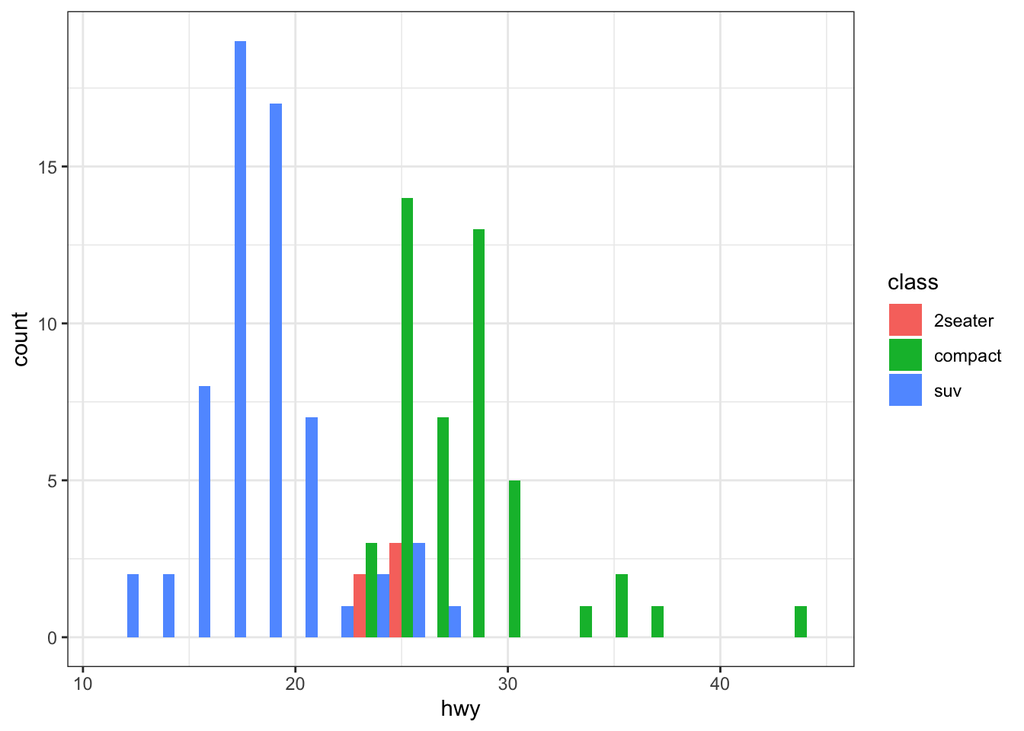

#### Boxplot

Create a boxplot for hwy for each of the 3 class

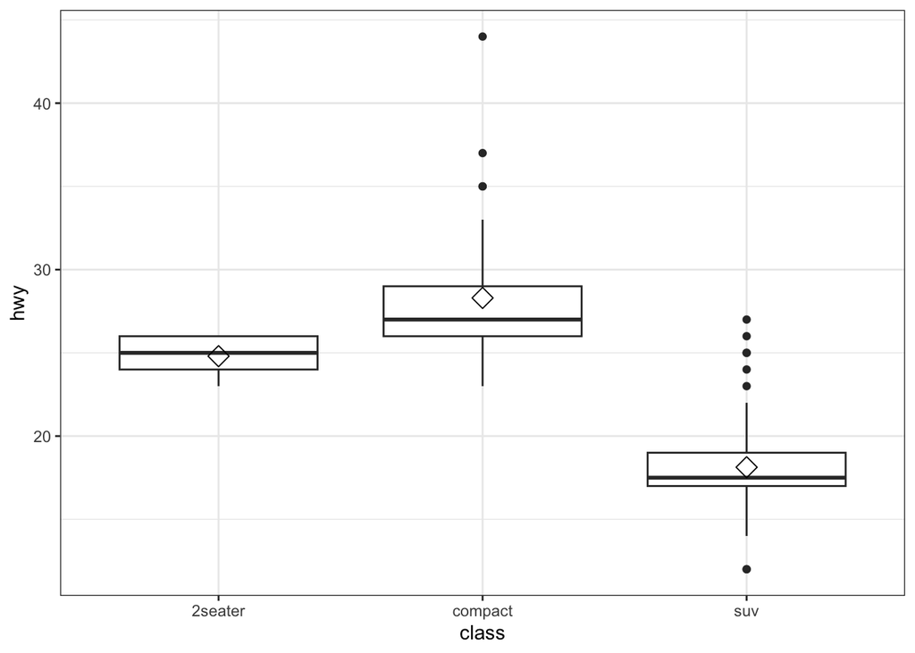

#### Bar Plot

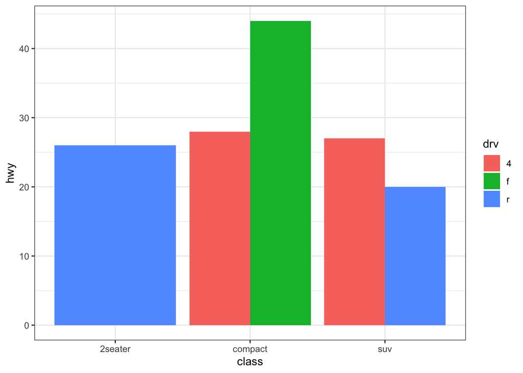

For some classes there are not enough observations to construct a bar. This is an unbalanced design, there is not an equal number of observations for each class.

#### Pie Chart

```
## # A tibble: 3 × 4
##   class       n percentage labels
##   <fct>   <int>      <dbl> <chr>
## 1 suv        62     0.544  54%
## 2 compact    47     0.412  41%
## 3 2seater     5     0.0439 4%
```

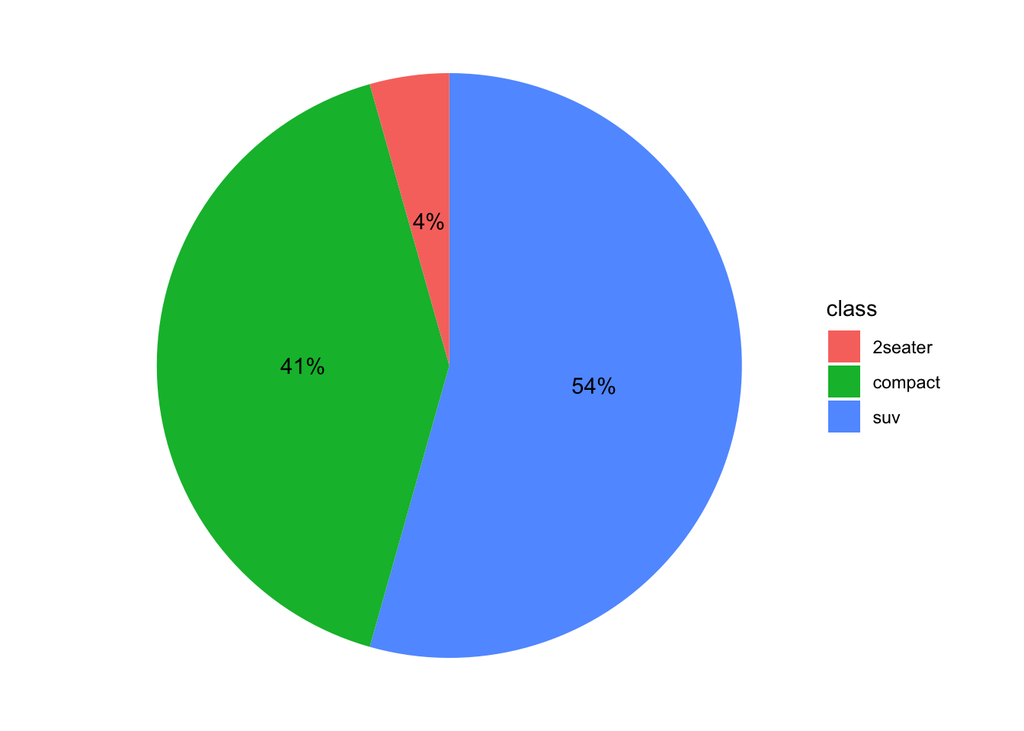

- group data via class, obtain counts for each class, compute percentages from counts, and arrange classes by their descending percentages - caution ungroup() is needed after group_by(…) %>% count() - The best selling chart is the pie chart?

- coord_polar converts bar plot into pie chart
- theme_void() mean “a completely empty theme; otherwise the resulting pie chart does not look nice
- geom_text adds labels to label different parts of a plot at their designated positions
- labels in mpg2 is used to label the slices.